# Reproducible Research - Week 4 - Project 2

# SYNOPSIS

Storms and other severe weather events can cause both public health and economic problems for communities and municipalities. Many severe events can result in fatalities, injuries, and property damage, and preventing such outcomes to the extent possible is a key concern.

I have conducted the following research using the data [47MB] from the NOAA Storm Database. The events in the database start in the year 1950 and end in November 2011. In the earlier years of the database there are generally fewer events recorded, most likely due to a lack of good records. More recent years should be considered more complete.

We are seeking to answer the following two questions with this information to help prevent, detect, and predict the impact on human lives as well as cost to our economy based on severe weather events.

1. Across the United States, which types of events (as indicated in the EVTYPE) harmful with respect to population health?
2. Across the United States, which types of events have the greatest economic consequences?

# RESULTS

Based on our Reproducible Research below - we have discovered the following:

- Tornados are the most harmful severe weather events to population health with respect to highest number of fatalities and injuries
- Floods are the most expensive severe weather events that have the greatest economic consequences

# DATA PROCESSING

Download the file

```r
setwd("C:/Users/Owner/Desktop/Data Science Specialization/C5-Reproducible Research/WEEK 4")
data<-read.csv("StormData.csv")
dim(data)
```

```
## [1] 902297     37
```

```r
head(data)
```

```
##   STATE__           BGN_DATE BGN_TIME TIME_ZONE COUNTY COUNTYNAME STATE
## 1       1  4/18/1950 0:00:00     0130       CST     97     MOBILE    AL
## 2       1  4/18/1950 0:00:00     0145       CST      3    BALDWIN    AL
## 3       1  2/20/1951 0:00:00     1600       CST     57    FAYETTE    AL
## 4       1   6/8/1951 0:00:00     0900       CST     89    MADISON    AL
## 5       1 11/15/1951 0:00:00     1500       CST     43    CULLMAN    AL
## 6       1 11/15/1951 0:00:00     2000       CST     77 LAUDERDALE    AL
##    EVTYPE BGN_RANGE BGN_AZI BGN_LOCATI END_DATE END_TIME COUNTY_END
## 1 TORNADO         0                                               0
## 2 TORNADO         0                                               0
## 3 TORNADO         0                                               0
## 4 TORNADO         0                                               0
## 5 TORNADO         0                                               0
## 6 TORNADO         0                                               0
##   COUNTYENDN END_RANGE END_AZI END_LOCATI LENGTH WIDTH F MAG FATALITIES
```

[output cut: 20 more lines]

We see that there is data we want to isolate for this particular analysis of damage based on EVTYPE (event type), FATALITIES, INJURIES, PROPDMG (property damage), PROPDMGEXP (property damage expense), CROPDMG (crop damage), and CROPDMGEXP (crop damage expense). We will isolate this data and store it in r object called “data_1.”

```r
data_1 <- data[,c('EVTYPE','FATALITIES','INJURIES', 'PROPDMG', 'PROPDMGEXP', 'CROPDMG', 'CROPDMGEXP')]
head(data_1)
```

```
##    EVTYPE FATALITIES INJURIES PROPDMG PROPDMGEXP CROPDMG CROPDMGEXP
## 1 TORNADO          0       15    25.0          K       0
## 2 TORNADO          0        0     2.5          K       0
## 3 TORNADO          0        2    25.0          K       0
## 4 TORNADO          0        2     2.5          K       0
## 5 TORNADO          0        2     2.5          K       0
## 6 TORNADO          0        6     2.5          K       0
```

```r
##Data looks a lot better now! We will now convert the PROPDMGEXP & CROPDMGEXP fields to tangible numbers where H (hundreds = 10^2), K (thousands = 10^3), M (millions = 10^6), and B (billions = 10^9) based on Wikipedia power of 10 table.
## Convert Property Damage
data_1$PROPDMGDOLLARS = 0
data_1[data_1$PROPDMGEXP == "H", ]$PROPDMGDOLLARS = data_1[data_1$PROPDMGEXP == "H", ]$PROPDMG * 10^2
data_1[data_1$PROPDMGEXP == "K", ]$PROPDMGDOLLARS = data_1[data_1$PROPDMGEXP == "K", ]$PROPDMG * 10^3
data_1[data_1$PROPDMGEXP == "M", ]$PROPDMGDOLLARS = data_1[data_1$PROPDMGEXP == "M", ]$PROPDMG * 10^6
data_1[data_1$PROPDMGEXP == "B", ]$PROPDMGDOLLARS = data_1[data_1$PROPDMGEXP == "B", ]$PROPDMG * 10^9
## Convert Crop Damage
data_1$CROPDMGDOLLARS = 0
data_1[data_1$CROPDMGEXP == "H", ]$CROPDMGDOLLARS = data_1[data_1$CROPDMGEXP == "H", ]$CROPDMG * 10^2
data_1[data_1$CROPDMGEXP == "K", ]$CROPDMGDOLLARS = data_1[data_1$CROPDMGEXP == "K", ]$CROPDMG * 10^3
data_1[data_1$CROPDMGEXP == "M", ]$CROPDMGDOLLARS = data_1[data_1$CROPDMGEXP == "M", ]$CROPDMG * 10^6
data_1[data_1$CROPDMGEXP == "B", ]$CROPDMGDOLLARS = data_1[data_1$CROPDMGEXP == "B", ]$CROPDMG * 10^9

## View revised headers of data_1
head(data_1)
```

```
##    EVTYPE FATALITIES INJURIES PROPDMG PROPDMGEXP CROPDMG CROPDMGEXP
## 1 TORNADO          0       15    25.0          K       0
## 2 TORNADO          0        0     2.5          K       0
## 3 TORNADO          0        2    25.0          K       0
## 4 TORNADO          0        2     2.5          K       0
## 5 TORNADO          0        2     2.5          K       0
## 6 TORNADO          0        6     2.5          K       0
##   PROPDMGDOLLARS CROPDMGDOLLARS
## 1          25000              0
## 2           2500              0
## 3          25000              0
## 4           2500              0
## 5           2500              0
## 6           2500              0
```

```r
## Now we have all of our data in a neat table:Event Types (EVTYPE),Fatalities,Injuries,Property Damage (PROPDMG),Property Damage Expense by symbol (PROPDMGEXP),Crop Damage (CROPDMG),Crop Damage Expense by symbol (CROPDMGEXP),Property Damage in Dollars by power of 10 (PROPDMGDOLLARS),Crop Damage in Dollars by power of 10 (CROPDMGDOLLARS)

##We will now use the data to answer the questions.
# Across the United States, which types of events (as indicated in the EVTYPE) are most harmful with respect to population health?

library (dplyr)
```

```r
library (ggplot2)
library("gridExtra")
## Organize type of event ~ fatalities and store in object "fatalities" & same for "injuries"
fatalities<-aggregate(FATALITIES ~ EVTYPE, data_1, sum)
injuries<-aggregate(INJURIES ~ EVTYPE, data_1, sum)

## Sort fatalities
fatalities <- fatalities[order(-fatalities$FATALITIES), ][1:20, ]
fatalities$EVTYPE <- factor(fatalities$EVTYPE, levels = fatalities$EVTYPE)
head(fatalities)
```

```
##             EVTYPE FATALITIES
## 834        TORNADO       5633
## 130 EXCESSIVE HEAT       1903
## 153    FLASH FLOOD        978
## 275           HEAT        937
## 464      LIGHTNING        816
## 856      TSTM WIND        504
```

```r
## Sort Injuries
injuries <- injuries[order(-injuries$INJURIES), ][1:20, ]
injuries$EVTYPE <- factor(injuries$EVTYPE, levels = injuries$EVTYPE)
head(injuries)
```

```
##             EVTYPE INJURIES
## 834        TORNADO    91346
## 856      TSTM WIND     6957
## 170          FLOOD     6789
## 130 EXCESSIVE HEAT     6525
## 464      LIGHTNING     5230
## 275           HEAT     2100
```

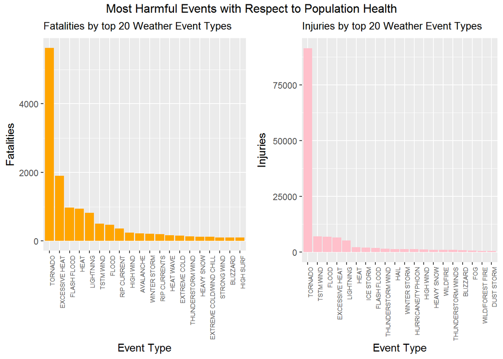

```r
## Plot using ggplot2
p1 = ggplot(fatalities, aes(x = EVTYPE, y = FATALITIES, theme_set(theme_bw()))) +
    geom_bar(stat = "identity", fill = "orange") +
    theme(axis.text.x = element_text(angle = 90, hjust = 1, size = 6)) +
    xlab("Event Type") + ylab("Fatalities") + ggtitle("Fatalities by top 20 Weather Event Types") +
    theme(plot.title = element_text(size = 10))

p2 = ggplot(injuries, aes(x = EVTYPE, y = INJURIES, theme_set(theme_bw()))) +
    geom_bar(stat = "identity", fill = "pink") +
    theme(axis.text.x = element_text(angle = 90, hjust = 1, size = 6)) +
    xlab("Event Type") + ylab("Injuries") + ggtitle("Injuries by top 20 Weather Event Types") +
    theme(plot.title = element_text(size = 10))


## Plot both side by side using gridExtra package
gridExtra::grid.arrange(p1, p2, ncol = 2, top = "Most Harmful Events with Respect to Population Health")
```

# By this chart we can conclude that Tornado as an event type has the highest level of Fatalities and Injuries.

# Across the United States, which types of events have the greatest economic consequences?

```r
## Organize Property & Crop to Event Type and store in object "economicConsq"
economicConsq <- aggregate(PROPDMGDOLLARS + CROPDMGDOLLARS ~ EVTYPE, data=data_1, sum)
names(economicConsq) = c("EVENT_TYPE", "Total_damage")
## Sort
economicConsq <- economicConsq[order(-economicConsq$Total_damage), ][1:20, ]
economicConsq$EVENT_TYPE <- factor(economicConsq$EVENT_TYPE, levels = economicConsq$EVENT_TYPE)

## Check headers
head(economicConsq)
```

```
##            EVENT_TYPE Total_damage
## 170             FLOOD 150319678250
## 411 HURRICANE/TYPHOON  71913712800
## 834           TORNADO  57340613590
## 670       STORM SURGE  43323541000
## 244              HAIL  18752904670
## 153       FLASH FLOOD  17562128610
```

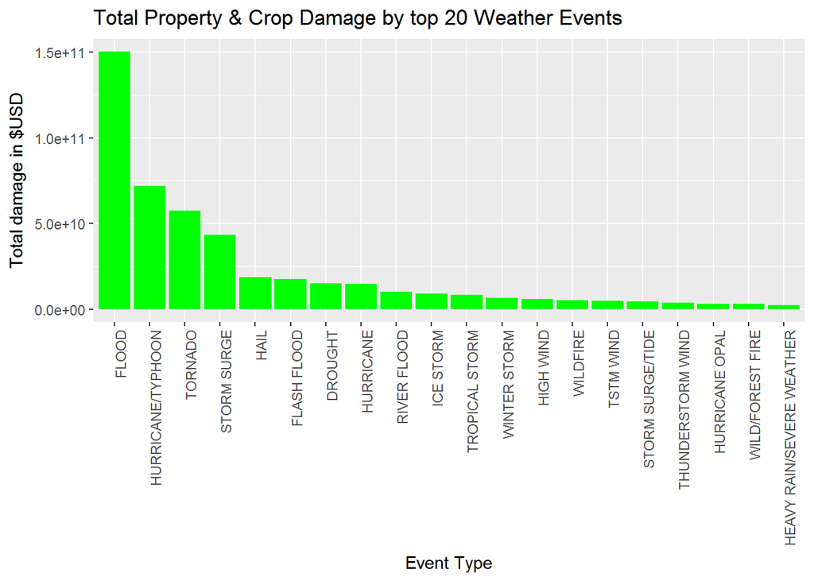

```r
## Plot using ggplot2

ggplot(economicConsq, aes(x = EVENT_TYPE, y = Total_damage, theme_set(theme_bw()))) +
    geom_bar(stat = "identity", fill = "green") +
    theme(axis.text.x = element_text(angle = 90, hjust = 1)) +
    xlab("Event Type") + ylab("Total damage in $USD") + ggtitle("Total Property & Crop Damage by top 20 Weather Events")
```

# Based on this chart we can concluded the the highest cost event type is Flood. This has the greatest (adverse) economic impact.